# Notebook

**EDA · Machine Learning · Clustering · Recomendaciones de negocio**

```python
import pandas as pd
import numpy as np
import math
import matplotlib.pyplot as plt
import seaborn as sns
from scipy.cluster.hierarchy import linkage, dendrogram
from sklearn.model_selection import train_test_split
from sklearn.preprocessing import StandardScaler
from sklearn.linear_model import LinearRegression, LogisticRegression
from sklearn.ensemble import RandomForestRegressor, RandomForestClassifier, GradientBoostingRegressor
from sklearn.tree import DecisionTreeRegressor
from sklearn.metrics import mean_absolute_error, mean_squared_error, r2_score, accuracy_score, roc_auc_score, precision_score, recall_score
from sklearn.cluster import KMeans
```

## Descargar los datos

```python
df = pd.read_csv('gym_churn_us.csv')
df.columns = (
    df.columns
      .str.strip()
      .str.lower()
      .str.strip('_')
)
print(df.info())
```

```
<class 'pandas.core.frame.DataFrame'>
RangeIndex: 4000 entries, 0 to 3999
Data columns (total 14 columns):
 #   Column                             Non-Null Count  Dtype
---  ------                             --------------  -----
 0   gender                             4000 non-null   int64
 1   near_location                      4000 non-null   int64
 2   partner                            4000 non-null   int64
 3   promo_friends                      4000 non-null   int64
 4   phone                              4000 non-null   int64
 5   contract_period                    4000 non-null   int64
 6   group_visits                       4000 non-null   int64
 7   age                                4000 non-null   int64
 8   avg_additional_charges_total       4000 non-null   float64
 9   month_to_end_contract              4000 non-null   float64
 10  lifetime                           4000 non-null   int64
 11  avg_class_frequency_total          4000 non-null   float64
 12  avg_class_frequency_current_month  4000 non-null   float64
 13  churn                              4000 non-null   int64
dtypes: float64(4), int64(10)
memory usage: 437.6 KB
None
```

## Análisis exploratorio de datos (EDA)

```python
## ¿El dataset contiene alguna característica ausente?

print(df.describe())
```

```
            gender  near_location      partner  promo_friends        phone  \
count  4000.000000    4000.000000  4000.000000    4000.000000  4000.000000
mean      0.510250       0.845250     0.486750       0.308500     0.903500
std       0.499957       0.361711     0.499887       0.461932     0.295313
min       0.000000       0.000000     0.000000       0.000000     0.000000
25%       0.000000       1.000000     0.000000       0.000000     1.000000
50%       1.000000       1.000000     0.000000       0.000000     1.000000
75%       1.000000       1.000000     1.000000       1.000000     1.000000
max       1.000000       1.000000     1.000000       1.000000     1.000000

       contract_period  group_visits          age  \
count      4000.000000   4000.000000  4000.000000
mean          4.681250      0.412250    29.184250
std           4.549706      0.492301     3.258367
min           1.000000      0.000000    18.000000
25%           1.000000      0.000000    27.000000
50%           1.000000      0.000000    29.000000
75%           6.000000      1.000000    31.000000
max          12.000000      1.000000    41.000000

       avg_additional_charges_total  month_to_end_contract     lifetime  \
count                   4000.000000            4000.000000  4000.000000
mean                     146.943728               4.322750     3.724750
std                       96.355602               4.191297     3.749267
min                        0.148205               1.000000     0.000000
25%                       68.868830               1.000000     1.000000
50%                      136.220159               1.000000     3.000000
75%                      210.949625               6.000000     5.000000
max                      552.590740              12.000000    31.000000

       avg_class_frequency_total  avg_class_frequency_current_month  \
count                4000.000000                        4000.000000
mean                    1.879020                           1.767052
std                     0.972245                           1.052906
min                     0.000000                           0.000000
25%                     1.180875                           0.963003
50%                     1.832768                           1.719574
75%                     2.536078                           2.510336
max                     6.023668                           6.146783

             churn
count  4000.000000
mean      0.265250
std       0.441521
min       0.000000
25%       0.000000
50%       0.000000
75%       1.000000
max       1.000000
```

```python
## Observa los valores medios de las características en dos grupos: para las personas que se fueron y para las que se quedaron.

groups = df.groupby('churn')
```

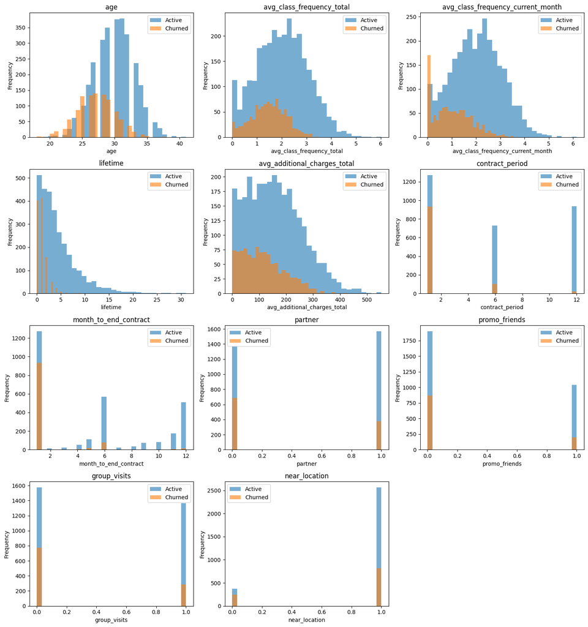

```python
## Traza histogramas de barras y distribuciones de características para aquellas personas que se fueron y para las que se quedaron.

features_to_plot = [
    'age',
    'avg_class_frequency_total',
    'avg_class_frequency_current_month',
    'lifetime',
    'avg_additional_charges_total',
    'contract_period',
    'month_to_end_contract',
    'partner',
    'promo_friends',
    'group_visits',
    'near_location'
]

n_cols = 3
n_rows = math.ceil(len(features_to_plot) / n_cols)

fig, axes = plt.subplots(n_rows, n_cols, figsize=(15, 4 * n_rows))
axes = axes.flatten()

for i, col in enumerate(features_to_plot):

    ax = axes[i]

    for churn_value, group in groups:
        label = 'Active' if churn_value == 0 else 'Churned'
        ax.hist(group[col], bins=30, alpha=0.6, label=label)

    ax.set_title(col)
    ax.set_xlabel(col)
    ax.set_ylabel('Frequency')
    ax.legend()

for j in range(i + 1, len(axes)):
    fig.delaxes(axes[j])

plt.tight_layout()
plt.show()
```

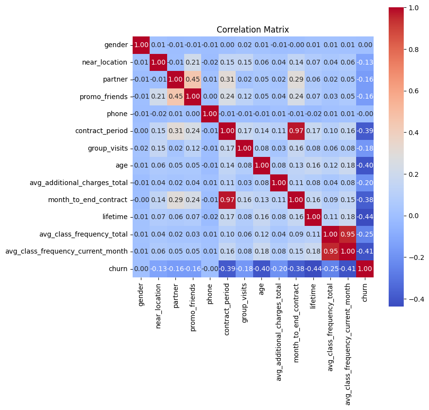

```python
# Matriz de correlación.

num_df = df.select_dtypes(include='number')

corr_matrix = num_df.corr()

plt.figure(figsize=(8, 8))
sns.heatmap(corr_matrix, annot=True, fmt='.2f', cmap='coolwarm', square=True)
plt.title('Correlation Matrix')
plt.show()
```

La matriz de correlación muestra que la cancelación de clientes está principalmente asociada con el nivel de compromiso y estabilidad del usuario. En particular, lifetime presenta la relación más fuerte con el churn (-0.44), seguida de la frecuencia de asistencia en el mes actual avg_class_frequency_current_month (-0.41), la edad (-0.40) y las condiciones contractuales, tanto contract_period (-0.39) como month_to_end_contract (-0.38). Estas relaciones indican que los clientes con menor tiempo de permanencia, menor participación reciente, contratos más cortos y de menor vigencia restante tienen una probabilidad significativamente mayor de cancelar su membresía.

Adicionalmente, variables como avg_class_frequency_total (-0.25), avg_additional_charges_total (-0.20), group_visits (-0.18), partner (-0.16) y promo_friends (-0.16) refuerzan la misma tendencia: a menor nivel de interacción, inversión y vínculo social, mayor propensión al churn. En conjunto, estos resultados confirman que el abandono ocurre predominantemente en las primeras etapas de la relación con el gimnasio y está impulsado por bajos niveles de engagement, proporcionando una base sólida y cuantificable para la construcción del modelo predictivo y para el diseño de estrategias de retención orientadas a fortalecer el compromiso temprano del cliente.

## Construir un modelo para predecir la cancelación de usuarios

```
Logistic Regression:
 Accuracy : 0.925
 Precision: 0.88
 Recall   : 0.83
 AUC-ROC  : 0.977

Random Forest:
 Accuracy : 0.925
 Precision: 0.884
 Recall   : 0.825
 AUC-ROC  : 0.968
```

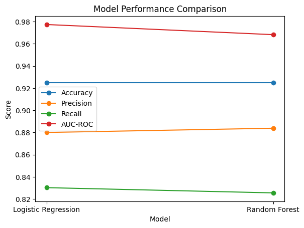

```python
# Dividir los datos en conjuntos de entrenamiento y validación

X = df.drop(columns=['churn'])
y = df['churn']

X_train, X_test, y_train, y_test = train_test_split(
    X, y, test_size=0.2, random_state=42, stratify=y
)

# Escalado de datos
scaler = StandardScaler()

X_train_scaled = scaler.fit_transform(X_train)
X_test_scaled = scaler.transform(X_test)

# Crear los modelos
log_model = LogisticRegression(max_iter=2000, random_state=42)
rf_model = RandomForestClassifier(random_state=42)

# Entrenar los modelos
log_model.fit(X_train_scaled, y_train)
rf_model.fit(X_train, y_train)

# Regresión Logística
log_preds = log_model.predict(X_test_scaled)

log_accuracy = accuracy_score(y_test, log_preds)
log_precision = precision_score(y_test, log_preds)
log_recall = recall_score(y_test, log_preds)

# Random Forest
rf_preds = rf_model.predict(X_test)

rf_accuracy = accuracy_score(y_test, rf_preds)
rf_precision = precision_score(y_test, rf_preds)
rf_recall = recall_score(y_test, rf_preds)

# Obtener probabilidades de predicción
log_probs = log_model.predict_proba(X_test_scaled)[:, 1]
rf_probs = rf_model.predict_proba(X_test)[:, 1]

# Calcular AUC-ROC
log_auc = roc_auc_score(y_test, log_probs)
rf_auc = roc_auc_score(y_test, rf_probs)

# Actualizar la presentación de resultados
print("Logistic Regression:")
print(" Accuracy :", round(log_accuracy, 3))
print(" Precision:", round(log_precision, 3))
print(" Recall   :", round(log_recall, 3))
print(" AUC-ROC  :", round(log_auc, 3))
print()

print("Random Forest:")
print(" Accuracy :", round(rf_accuracy, 3))
print(" Precision:", round(rf_precision, 3))
print(" Recall   :", round(rf_recall, 3))
print(" AUC-ROC  :", round(rf_auc, 3))

models = ['Logistic Regression', 'Random Forest']

accuracy = [log_accuracy, rf_accuracy]
precision = [log_precision, rf_precision]
recall = [log_recall, rf_recall]
auc = [log_auc, rf_auc]

x = range(len(models))

plt.figure()

plt.plot(x, accuracy, marker='o', label='Accuracy')
plt.plot(x, precision, marker='o', label='Precision')
plt.plot(x, recall, marker='o', label='Recall')
plt.plot(x, auc, marker='o', label='AUC-ROC')

plt.xticks(list(x), models)
plt.xlabel('Model')
plt.ylabel('Score')
plt.title('Model Performance Comparison')
plt.legend()

plt.show()
```

## Crear clústeres de usuarios/as

```python
# Preparar datos para clustering

X_clustering = df.drop(columns=['churn'])
scaler_clustering = StandardScaler()
X_clustering_scaled = scaler_clustering.fit_transform(X_clustering)
```

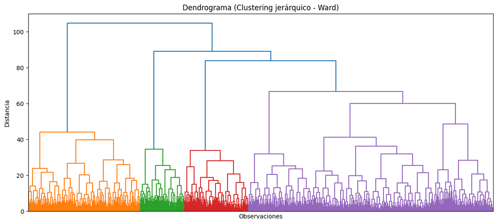

```python
# Aplicar la función linkage
linkage_matrix = linkage(X_clustering_scaled, method='ward')

# Dendrograma completo
plt.figure(figsize=(14, 6))
dendrogram(linkage_matrix, no_labels=True)
plt.title('Dendrograma (Clustering jerárquico - Ward)')
plt.xlabel('Observaciones')
plt.ylabel('Distancia')
plt.show()
```

```python
# Entrenamiento del modelo de clustering con el algortimo K-means.

kmeans = KMeans(n_clusters=5, random_state=42)
cluster_labels = kmeans.fit_predict(X_clustering_scaled)
```

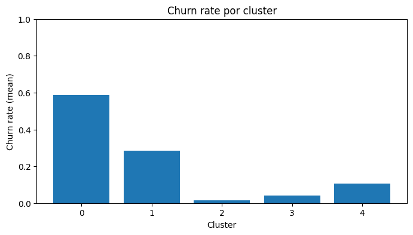

```python
# valores medios de característica para los clústeres.

# Agregar las etiquetas de clúster al DataFrame
df_with_clusters = df.copy()
df_with_clusters['cluster'] = cluster_labels

# Churn por clúster
churn_by_cluster = df_with_clusters.groupby('cluster')['churn'].mean().sort_index()

plt.figure(figsize=(8, 4))
plt.bar(churn_by_cluster.index, churn_by_cluster.values)

plt.title('Churn rate por cluster')
plt.xlabel('Cluster')
plt.ylabel('Churn rate (mean)')
plt.ylim(0, 1)

plt.show()
```

```python
cols = [
    'contract_period',
    'month_to_end_contract',
    'lifetime',
    'avg_class_frequency_total',
    'avg_class_frequency_current_month',
    'group_visits',
    'promo_friends',
    'partner',
    'churn'
]

cluster_summary = (
    df_with_clusters
    .groupby('cluster')[cols]
    .mean()
)

# Para que el churn sea verificable como porcentaje con 1 decimal:
cluster_summary_display = cluster_summary.copy()
cluster_summary_display['churn_%'] = (cluster_summary_display['churn'] * 100).round(1)
cluster_summary_display = cluster_summary_display.drop(columns=['churn']).round(2)

display(cluster_summary_display)
```

| cluster | contract_period | month_to_end_contract | lifetime | avg_class_frequency_total | avg_class_frequency_current_month | group_visits | promo_friends | partner | churn_% |
| --- | --- | --- | --- | --- | --- | --- | --- | --- | --- |
| 0 | 1.73 | 1.66 | 2.09 | 1.26 | 0.99 | 0.26 | 0.01 | 0.30 | 58.8 |
| 1 | 2.74 | 2.54 | 3.53 | 1.62 | 1.49 | 0.43 | 1.00 | 0.79 | 28.6 |
| 2 | 10.50 | 9.48 | 4.69 | 2.89 | 2.89 | 0.51 | 0.49 | 0.77 | 1.4 |
| 3 | 11.19 | 10.35 | 4.82 | 1.15 | 1.14 | 0.58 | 0.42 | 0.74 | 4.2 |
| 4 | 2.12 | 2.01 | 4.84 | 2.67 | 2.65 | 0.46 | 0.05 | 0.18 | 10.5 |

Cluster 2 — Cliente ideal / premium

Churn ≈ 1.4 %

Este grupo representa a los clientes más valiosos y estables del negocio. Presentan contratos largos (contract_period = 10.50 meses, month_to_end_contract = 9.48 meses), la mayor frecuencia de uso del servicio (avg_class_frequency_current_month = 2.89) y una alta integración social (group_visits = 0.51, promo_friends = 0.49).

Su nivel de churn prácticamente nulo refleja una relación sólida y madura con el gimnasio, donde el cliente percibe alto valor y mantiene hábitos de uso plenamente consolidados.

Churn ≈ 28.6 %

Estos clientes han desarrollado una rutina relativamente estable y sostienen un vínculo operativo consistente con el servicio, lo que mitiga parcialmente el riesgo de cancelación asociado a su menor duración contractual.

Cluster 0 — Cliente de alto riesgo

Churn ≈ 58.8 %

Este es el grupo con mayor probabilidad de abandono. Se caracteriza por contratos muy cortos (contract_period = 1.73 meses), baja frecuencia de uso (avg_class_frequency_current_month = 0.99), baja integración social (group_visits = 0.26, promo_friends = 0.01) y una permanencia extremadamente reducida (lifetime = 2.09 meses).

Este perfil describe clientes poco comprometidos, con hábitos débiles y mínima vinculación social, lo que los convierte en la principal prioridad de intervención y retención.

Cluster 4 — Cliente de valor medio con riesgo latente

Churn ≈ 10.5 %

Estos clientes muestran una buena frecuencia de uso (avg_class_frequency_current_month = 2.65) y una permanencia considerable (lifetime = 4.84 meses), pero mantienen contratos relativamente cortos (contract_period = 2.12 meses) y baja integración social (promo_friends = 0.05).

Aunque su churn es inferior al de los clusters 0 y 1, su perfil indica un nivel de compromiso aún frágil, lo que sugiere oportunidades claras de fortalecimiento mediante programas de fidelización.

Cluster 3 — Cliente de alta estabilidad contractual

Churn ≈ 4.2 %

Este segmento presenta los contratos más largos del sistema (contract_period = 11.19 meses, month_to_end_contract = 10.35 meses) y una elevada permanencia (lifetime = 4.82 meses), aunque con una frecuencia de uso moderada (avg_class_frequency_current_month = 1.14).

Se trata de clientes estructuralmente estables que mantienen su vínculo principalmente a través del compromiso contractual, incluso cuando su actividad operativa no es tan alta como la del Cluster 2.

## Conclusiones y recomendaciones básicas sobre el trabajo con clientes

El Cluster 0 se identifica como el segmento de mayor riesgo, con una tasa de churn cercana al 58.8 %, explicada principalmente por un compromiso contractual y operativo extremadamente bajo. Este grupo presenta el contract_period más corto del sistema (1.73 meses) y un month_to_end_contract de 1.66 meses, lo que indica clientes con vínculos contractuales débiles desde el inicio.

Además, muestran el menor nivel de engagement del conjunto, con avg_class_frequency_total = 1.26, avg_class_frequency_current_month = 0.99 y group_visits = 0.26, todos entre los valores más bajos de los clústeres. A esto se suma un perfil de clientes muy recientes y poco vinculados, con lifetime = 2.09 meses, promo_friends = 0.01 y partner = 0.30, lo que refleja una integración social y comercial mínima con el servicio.

En contraste, el Cluster 2, el más estable y valioso, registra un churn de apenas 1.4 %, sustentado por condiciones opuestas: contract_period = 10.50 meses (más de seis veces superior al del Cluster 0), month_to_end_contract = 9.48 meses y una participación significativamente mayor con avg_class_frequency_current_month = 2.89, casi tres veces la actividad observada en el segmento de mayor riesgo.

Esta comparación demuestra que la combinación de contratos largos y alto engagement temprano es determinante para la retención y el valor de vida del cliente.

A partir de estos hallazgos, se recomienda implementar estrategias específicas para el Cluster 0, enfocadas en intervenir durante los primeros meses de relación: extensiones contractuales con incentivos, programas de onboarding intensivo, sesiones de acompañamiento inicial, beneficios por referidos y actividades grupales que fortalezcan la integración social. Dado que este segmento concentra la mayor pérdida potencial de clientes, una intervención temprana y focalizada puede generar un impacto significativo en la reducción global del churn.